# Analisis CRISP-DM: "Rain in Australia"

[figure not shown]

### **Equipo: Nando y los SQL**

**Integrantes:**

- Cristian Contreras
- Esteban Diaz
- Marian Moreno

## Fase 1: Business Understanding

### Contexto del Caso

#### Predicción de la Lluvia en Australia

El objetivo de este proyecto es desarrollar un modelo predictivo para pronosticar la cantidad de lluvia y la probabilidad de lluvia al día siguiente en diversas ubicaciones de Australia. Utilizando el conjunto de datos "Rain in Australia"

### Carga de dataset y dependencias

```python
import pandas as pd
import numpy as np
import matplotlib.pyplot as plt
import seaborn as sns
import warnings
# import KNNImputer from scikit-learn
from sklearn.impute import KNNImputer
from sklearn.tree import DecisionTreeClassifier
from imblearn.over_sampling import SMOTE
from sklearn.preprocessing import MinMaxScaler
from sklearn.model_selection import train_test_split





#Carga de dataset
#usar plot modo claro
df_original = pd.read_csv('https://raw.githubusercontent.com/Nandocho8/Mineria/main/rain_to_australia/temperatura.csv', sep=',', low_memory=False)
df = df_original.copy()
df.head()
```

|  | Date | Location | MinTemp | MaxTemp | Rainfall | Evaporation | Sunshine | WindGustDir | WindGustSpeed | WindDir9am | ... | Humidity3pm | Pressure9am | Pressure3pm | Cloud9am | Cloud3pm | Temp9am | Temp3pm | RainToday | RISK_MM | RainTomorrow |
| --- | --- | --- | --- | --- | --- | --- | --- | --- | --- | --- | --- | --- | --- | --- | --- | --- | --- | --- | --- | --- | --- |
| 0 | 2008-12-01 | Albury | 13.4 | 22.9 | 0.6 | NaN | NaN | W | 44.0 | W | ... | 22.0 | 1007.7 | 1007.1 | 8.0 | NaN | 16.9 | 21.8 | No | 0.0 | No |
| 1 | 2008-12-02 | Albury | 7.4 | 25.1 | 0.0 | NaN | NaN | WNW | 44.0 | NNW | ... | 25.0 | 1010.6 | 1007.8 | NaN | NaN | 17.2 | 24.3 | No | 0.0 | No |
| 2 | 2008-12-03 | Albury | 12.9 | 25.7 | 0.0 | NaN | NaN | WSW | 46.0 | W | ... | 30.0 | 1007.6 | 1008.7 | NaN | 2.0 | 21.0 | 23.2 | No | 0.0 | No |
| 3 | 2008-12-04 | Albury | 9.2 | 28.0 | 0.0 | NaN | NaN | NE | 24.0 | SE | ... | 16.0 | 1017.6 | 1012.8 | NaN | NaN | 18.1 | 26.5 | No | 1.0 | No |
| 4 | 2008-12-05 | Albury | 17.5 | 32.3 | 1.0 | NaN | NaN | W | 41.0 | ENE | ... | 33.0 | 1010.8 | 1006.0 | 7.0 | 8.0 | 17.8 | 29.7 | No | 0.2 | No |

5 rows × 24 columns

Teniendo asi la información de las columnas

| Variable | Descripción | Columna dataset |
| --- | --- | --- |
| Fecha | Fecha de la observación | Date |
| Ubicación | Ubicación de la estación meteorológica | Location |
| MinTemp | Temperatura mínima en grados Celsius | MinTemp |
| MaxTemp | Temperatura máxima en grados Celsius | MaxTemp |
| Lluvia | Cantidad de lluvia registrada ese día en mm. | Rainfall |
| Evaporación | Evaporación (mm) en 24 horas | Evaporation |
| Sol | Número de horas de sol brillante en el día | Sunshine |
| DirRafaga | Dirección de la ráfaga de viento más fuerte en 24 horas | WindGustDir |
| VelRafaga | Velocidad (km/hr) de la ráfaga de viento más fuerte en 24 horas | WindGustSpeed |
| Dir9am | Dirección del viento a las 9am | WindDir9am |
| Dir3pm | Dirección del viento a las 3pm | WindDir3pm |
| Vel9am | Velocidad (km/hr) del viento a las 9am | WindSpeed9am |
| Vel3pm | Velocidad (km/hr) del viento a las 3pm | WindSpeed3pm |
| Hum9am | Porcentaje de humedad a las 9am | Humidity9am |
| Hum3pm | Porcentaje de humedad a las 3pm | Humidity3pm |
| Pres9am | Presión atmosférica (hpa) a nivel del mar a las 9am | Pressure9am |
| Pres3pm | Presión atmosférica (hpa) a nivel del mar a las 3pm | Pressure3pm |
| Nub9am | Fracción del cielo cubierto por nubes a las 9am. Se mide en "octavos", de manera que un valor 0 indica cielo totalmente despejado y 8, cielo totalmente cubierto. | Cloud9am |
| Nub3pm | Fracción del cielo cubierto por nubes a las 3pm. Se mide en "octavos", de manera que un valor 0 indica cielo totalmente despejado y 8, cielo totalmente cubierto. | Cloud3pm |
| Temp9am | Temperatura en grados Celsius a las 9am | Temp9am |
| Temp3pm | Temperatura en grados Celsius a las 3pm | Temp3pm |
| Lluvia Hoy | Variable indicadora que toma el valor 1 si la precipitación en mm. en las últimas 24 hrs. excede 1 mm. y 0 si no. | RainToday |
| RISK_MM | La cantidad de lluvia. Una especie de medida del "riesgo". | RISK_MM |
| Lluvia Man | Variable indicadora que toma el valor 1 si al día siguiente llovió y 0 si no | RainTomorrow |

**Teniendo asi que predecir las columnas *RISK_MM* y *RainTomorrow*.**

### Información del Dataset

#### Tipos de datos

```python
df.info()
```

[output not shown]

**El dataset consta de 142.193 rows y 24 columns, con la información entregada notamos que deberemos realizar un modelo predictivo de regresión para RISK_MM y de clasificación para RainTomorrrow.**

## Fase 2: Data Understanding

### Analisis Estadistico

#### Analisis de las variables numéricas

```python
df.describe().T
```

|  | count | mean | std | min | 25% | 50% | 75% | max |
| --- | --- | --- | --- | --- | --- | --- | --- | --- |
| MinTemp | 141556.0 | 12.186400 | 6.403283 | -8.5 | 7.6 | 12.0 | 16.8 | 33.9 |
| MaxTemp | 141871.0 | 23.226784 | 7.117618 | -4.8 | 17.9 | 22.6 | 28.2 | 48.1 |
| Rainfall | 140787.0 | 2.349974 | 8.465173 | 0.0 | 0.0 | 0.0 | 0.8 | 371.0 |
| Evaporation | 81350.0 | 5.469824 | 4.188537 | 0.0 | 2.6 | 4.8 | 7.4 | 145.0 |
| Sunshine | 74377.0 | 7.624853 | 3.781525 | 0.0 | 4.9 | 8.5 | 10.6 | 14.5 |
| WindGustSpeed | 132923.0 | 39.984292 | 13.588801 | 6.0 | 31.0 | 39.0 | 48.0 | 135.0 |
| WindSpeed9am | 140845.0 | 14.001988 | 8.893337 | 0.0 | 7.0 | 13.0 | 19.0 | 130.0 |
| WindSpeed3pm | 139563.0 | 18.637576 | 8.803345 | 0.0 | 13.0 | 19.0 | 24.0 | 87.0 |
| Humidity9am | 140419.0 | 68.843810 | 19.051293 | 0.0 | 57.0 | 70.0 | 83.0 | 100.0 |
| Humidity3pm | 138583.0 | 51.482606 | 20.797772 | 0.0 | 37.0 | 52.0 | 66.0 | 100.0 |
| Pressure9am | 128179.0 | 1017.653758 | 7.105476 | 980.5 | 1012.9 | 1017.6 | 1022.4 | 1041.0 |
| Pressure3pm | 128212.0 | 1015.258204 | 7.036677 | 977.1 | 1010.4 | 1015.2 | 1020.0 | 1039.6 |
| Cloud9am | 88536.0 | 4.437189 | 2.887016 | 0.0 | 1.0 | 5.0 | 7.0 | 9.0 |
| Cloud3pm | 85099.0 | 4.503167 | 2.720633 | 0.0 | 2.0 | 5.0 | 7.0 | 9.0 |
| Temp9am | 141289.0 | 16.987509 | 6.492838 | -7.2 | 12.3 | 16.7 | 21.6 | 40.2 |
| Temp3pm | 139467.0 | 21.687235 | 6.937594 | -5.4 | 16.6 | 21.1 | 26.4 | 46.7 |
| RISK_MM | 142193.0 | 2.360682 | 8.477969 | 0.0 | 0.0 | 0.0 | 0.8 | 371.0 |

#### Analisis de las variables categoricas

```python
df.describe(include='object').T
```

|  | count | unique | top | freq |
| --- | --- | --- | --- | --- |
| Date | 142193 | 3436 | 2013-12-01 | 49 |
| Location | 142193 | 49 | Canberra | 3418 |
| WindGustDir | 132863 | 16 | W | 9780 |
| WindDir9am | 132180 | 16 | N | 11393 |
| WindDir3pm | 138415 | 16 | SE | 10663 |
| RainToday | 140787 | 2 | No | 109332 |
| RainTomorrow | 142193 | 2 | No | 110316 |

### Correlacion de los datos

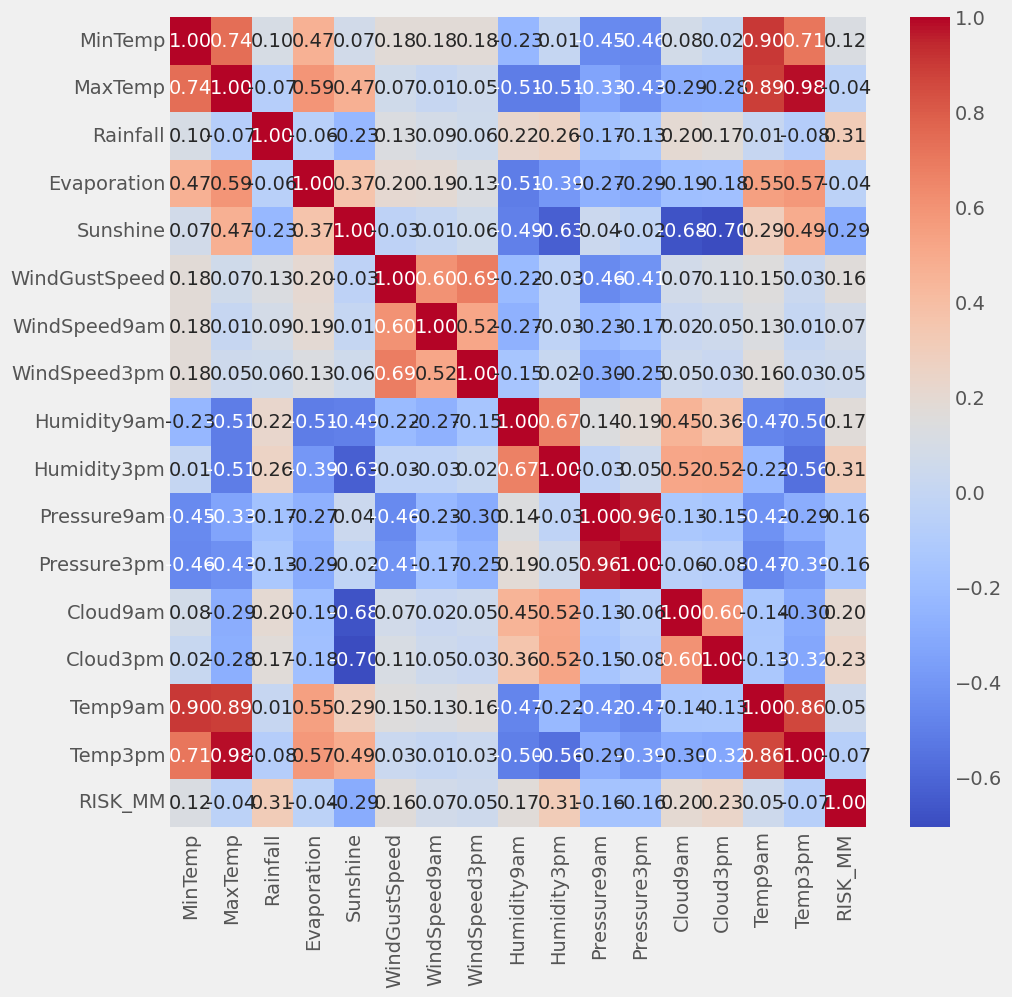

```python
# # matriz de corelacion de las variables  numericas menos fecha

# dataset solo de columnas tipo float
# crear un df_correlation con todo el data set menos con date y location
df_correlation = df.drop(columns=['Date', 'Location', 'WindGustDir', 'WindDir9am', 'WindDir3pm','RainTomorrow', 'RainToday'], axis=1)
# crear una matriz de correlacion
correlation = df_correlation.corr()
# graficar la matriz de correlacion
plt.figure(figsize=(10,10))
sns.heatmap(correlation, annot=True, cmap='coolwarm', fmt=".2f")
plt.show()
```

### Tipos de datos

#### 1. Gráfico por tipo de datos

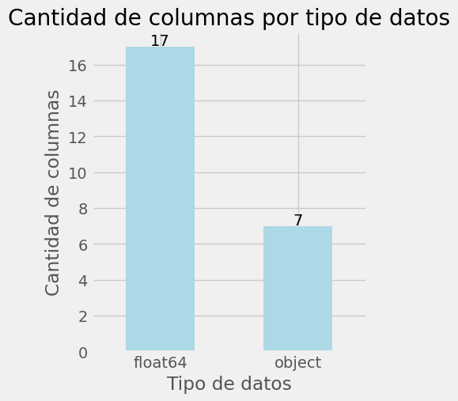

```python
plt.style.use('dark_background')
plt.style.use('ggplot')
plt.style.use('fivethirtyeight')

type_counts = df.dtypes.value_counts()
plt.figure(figsize=(4, 5))
ax = type_counts.plot(kind='bar', color='lightblue')
for p in ax.patches:
    ax.annotate(str(p.get_height()), (p.get_x() + p.get_width() / 2., p.get_height()),
                ha='center', va='center', xytext=(0, 5), textcoords='offset points', color='black', )


plt.title('Cantidad de columnas por tipo de datos', color='black')
plt.xlabel('Tipo de datos')
plt.ylabel('Cantidad de columnas')
plt.xticks(rotation=0)
plt.show()
```

#### 2. Revisión de datos tipo float

```python
# dataset solo de columnas tipo float
df_float = df.select_dtypes(include=['float64'])
## dataset con la columna, cantidad total de valores, la cantidad de nulos y el porcentaje de nulos
df_float_info = pd.DataFrame(df_float.columns, columns=['column_name'])
df_float_info['total_values'] = df_float.count().values + df_float.isnull().sum().values
df_float_info['null_values'] = df_float.isnull().sum().values
df_float_info['null_percentage'] = (df_float.isnull().sum().values / (df_float.count().values + df_float.isnull().sum().values)) * 100
df_float_info.sort_values(by='null_percentage', ascending=False, inplace=True)
df_float_info.reset_index(drop=True, inplace=True)
# obtener una lista con las column_name que tienen valores nulos ordenados de menor a mayor
list_columns_nulls = df_float_info[df_float_info['null_values'] > 0]['column_name'].values[::-1]
df_float_info
```

[output not shown]

### 3. Outliers

Función para graficar outliers

```python
def graph_iqr_outliers(ax, df , col , outlier_range):
    q25 = df[col].quantile(0.25)
    q75 = df[col].quantile(0.75)
    iqr = q75 - q25
    lower_bound = q25 -  outlier_range* iqr
    upper_bound = q75 + outlier_range * iqr
    outliers = df[(df[col] < lower_bound) | (df[col] > upper_bound)].shape[0]
    percentage = outliers / df[col].count() * 100
    sns.boxplot(x=df[col], color='lightblue', ax=ax)
    ax.set_title(f'{col}\n{outlier_range} IQR', color='black')
    ax.axvline(lower_bound, color='red', linestyle='--')
    ax.axvline(upper_bound, color='red', linestyle='--')
    print(f"Si tomamos {outlier_range} veces el rango intercuartílico, los límites son {lower_bound:.2f} y {upper_bound:.2f}. Tenemos {outliers:.0f} outliers, lo que representa un {percentage:.2f}% del total de valores.")

    return lower_bound, upper_bound, outliers
```

#### Grafico de los outliers

```
Si tomamos 1.5 veces el rango intercuartílico, los límites son -6.20 y 30.60. Tenemos 62 outliers, lo que representa un 0.04% del total de valores.
Si tomamos 3 veces el rango intercuartílico, los límites son -20.00 y 44.40. Tenemos 0 outliers, lo que representa un 0.00% del total de valores.
```

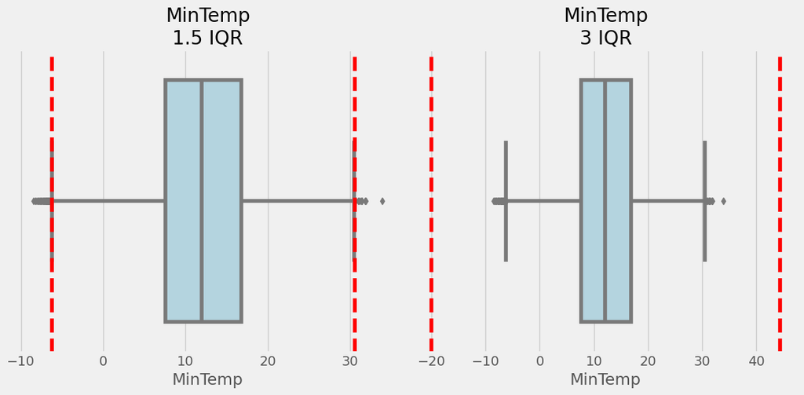

```
Si tomamos 1.5 veces el rango intercuartílico, los límites son 2.45 y 43.65. Tenemos 459 outliers, lo que representa un 0.32% del total de valores.
Si tomamos 3 veces el rango intercuartílico, los límites son -13.00 y 59.10. Tenemos 0 outliers, lo que representa un 0.00% del total de valores.
```

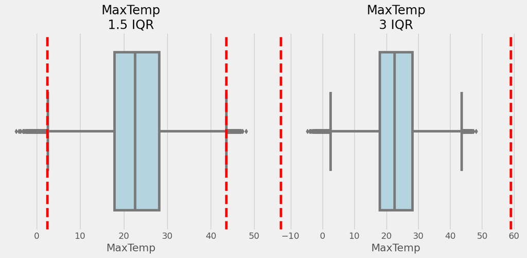

```
Si tomamos 1.5 veces el rango intercuartílico, los límites son -1.20 y 2.00. Tenemos 25228 outliers, lo que representa un 17.92% del total de valores.
Si tomamos 3 veces el rango intercuartílico, los límites son -2.40 y 3.20. Tenemos 20462 outliers, lo que representa un 14.53% del total de valores.
```

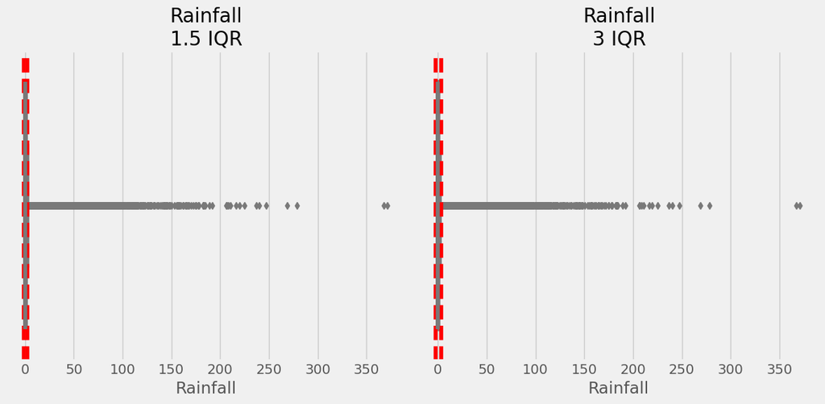

```
Si tomamos 1.5 veces el rango intercuartílico, los límites son -4.60 y 14.60. Tenemos 1954 outliers, lo que representa un 2.40% del total de valores.
Si tomamos 3 veces el rango intercuartílico, los límites son -11.80 y 21.80. Tenemos 471 outliers, lo que representa un 0.58% del total de valores.
```

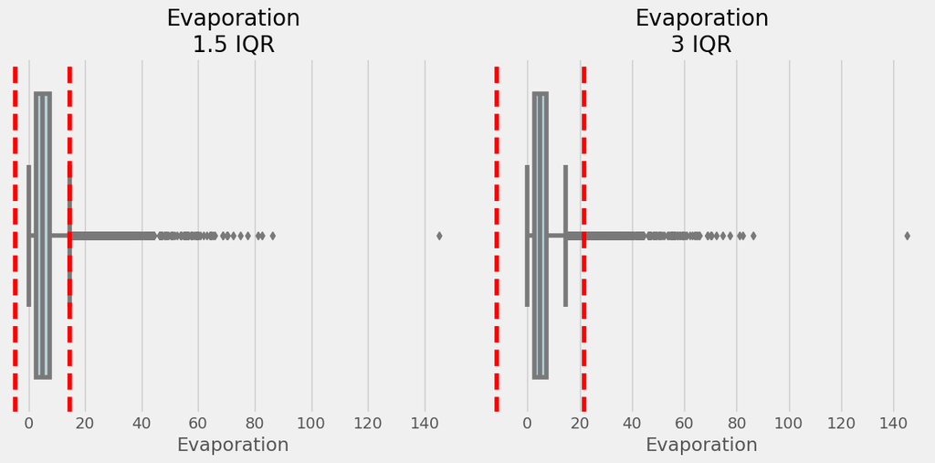

```
Si tomamos 1.5 veces el rango intercuartílico, los límites son -3.65 y 19.15. Tenemos 0 outliers, lo que representa un 0.00% del total de valores.
Si tomamos 3 veces el rango intercuartílico, los límites son -12.20 y 27.70. Tenemos 0 outliers, lo que representa un 0.00% del total de valores.
```

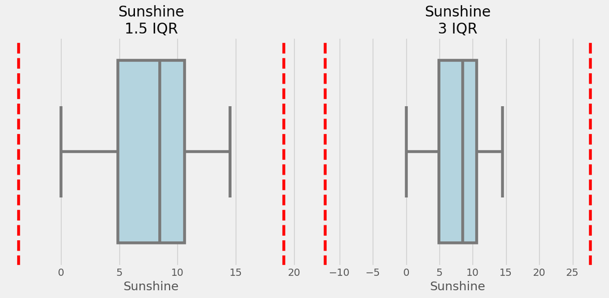

```
Si tomamos 1.5 veces el rango intercuartílico, los límites son 5.50 y 73.50. Tenemos 3006 outliers, lo que representa un 2.26% del total de valores.
Si tomamos 3 veces el rango intercuartílico, los límites son -20.00 y 99.00. Tenemos 150 outliers, lo que representa un 0.11% del total de valores.
```

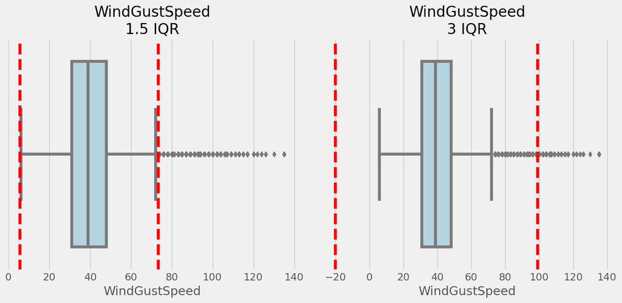

```
Si tomamos 1.5 veces el rango intercuartílico, los límites son -11.00 y 37.00. Tenemos 1739 outliers, lo que representa un 1.23% del total de valores.
Si tomamos 3 veces el rango intercuartílico, los límites son -29.00 y 55.00. Tenemos 107 outliers, lo que representa un 0.08% del total de valores.
```

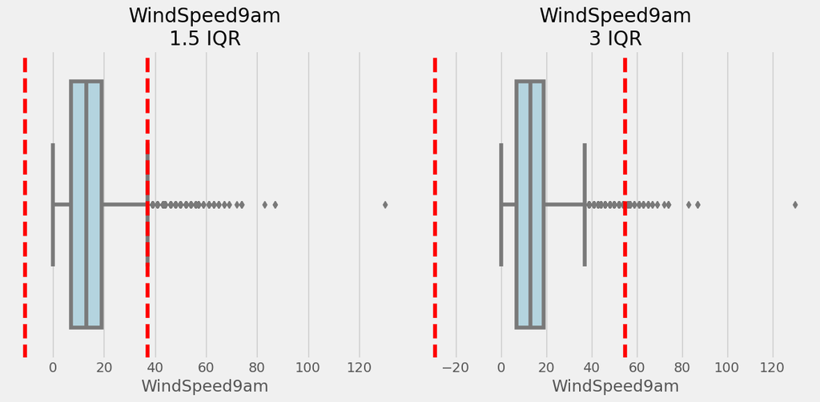

```
Si tomamos 1.5 veces el rango intercuartílico, los límites son -3.50 y 40.50. Tenemos 2458 outliers, lo que representa un 1.76% del total de valores.
Si tomamos 3 veces el rango intercuartílico, los límites son -20.00 y 57.00. Tenemos 81 outliers, lo que representa un 0.06% del total de valores.
```

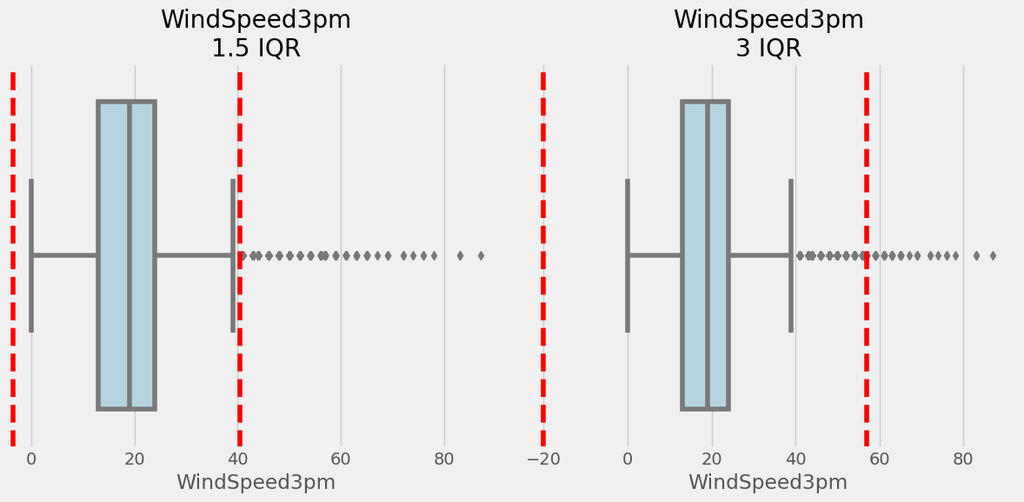

```
Si tomamos 1.5 veces el rango intercuartílico, los límites son 18.00 y 122.00. Tenemos 1419 outliers, lo que representa un 1.01% del total de valores.
Si tomamos 3 veces el rango intercuartílico, los límites son -21.00 y 161.00. Tenemos 0 outliers, lo que representa un 0.00% del total de valores.
```

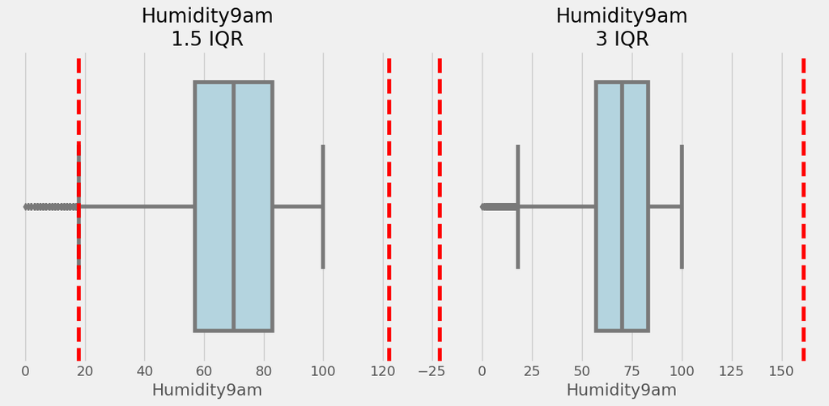

```
Si tomamos 1.5 veces el rango intercuartílico, los límites son -6.50 y 109.50. Tenemos 0 outliers, lo que representa un 0.00% del total de valores.
Si tomamos 3 veces el rango intercuartílico, los límites son -50.00 y 153.00. Tenemos 0 outliers, lo que representa un 0.00% del total de valores.
```

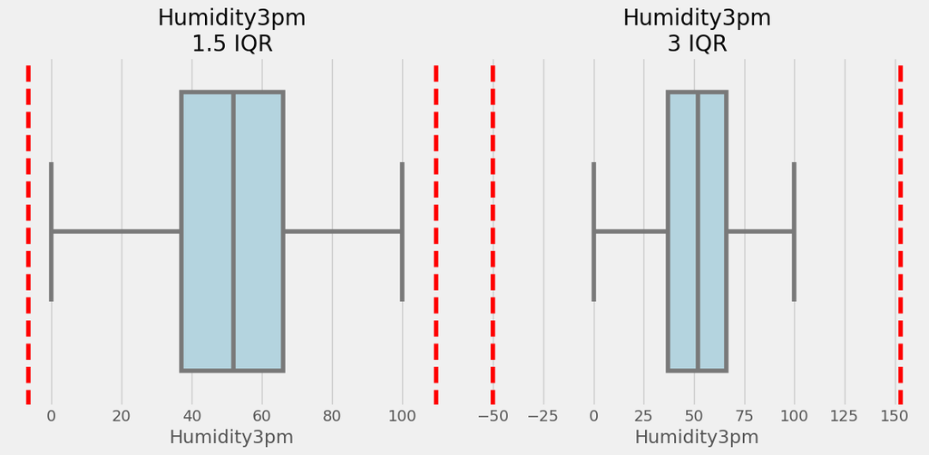

```
Si tomamos 1.5 veces el rango intercuartílico, los límites son 998.65 y 1036.65. Tenemos 1174 outliers, lo que representa un 0.92% del total de valores.
Si tomamos 3 veces el rango intercuartílico, los límites son 984.40 y 1050.90. Tenemos 8 outliers, lo que representa un 0.01% del total de valores.
```

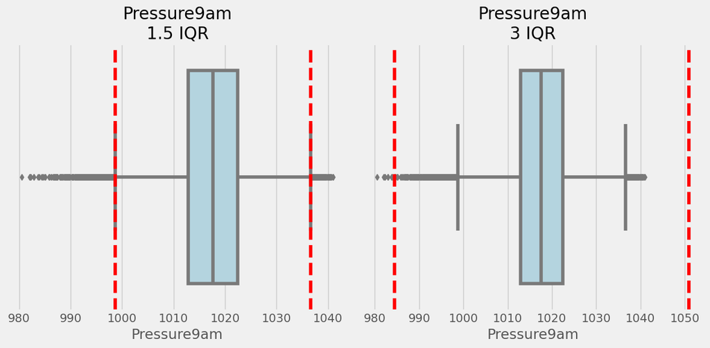

```
Si tomamos 1.5 veces el rango intercuartílico, los límites son 996.00 y 1034.40. Tenemos 906 outliers, lo que representa un 0.71% del total de valores.
Si tomamos 3 veces el rango intercuartílico, los límites son 981.60 y 1048.80. Tenemos 7 outliers, lo que representa un 0.01% del total de valores.
```

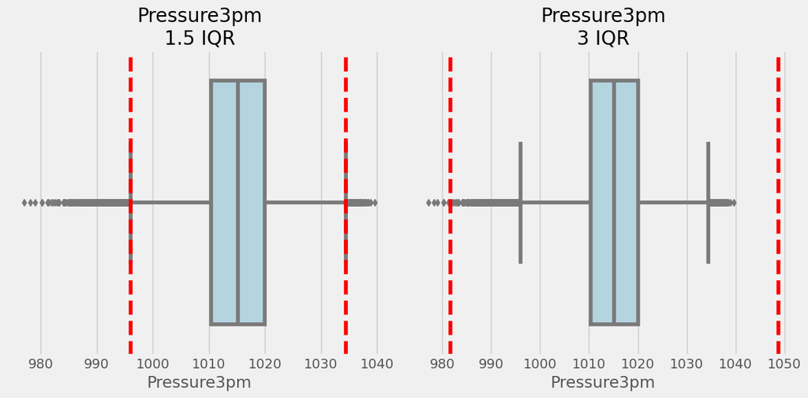

```
Si tomamos 1.5 veces el rango intercuartílico, los límites son -8.00 y 16.00. Tenemos 0 outliers, lo que representa un 0.00% del total de valores.
Si tomamos 3 veces el rango intercuartílico, los límites son -17.00 y 25.00. Tenemos 0 outliers, lo que representa un 0.00% del total de valores.
```

[5 more figures not shown]

```python
warnings.filterwarnings("ignore", category=FutureWarning)
info_outliers = []
for col in df_float.columns:
    fig , axs = plt.subplots(1, 2, figsize=(12, 6))
    q25_15 , q75_15 , out_15 = graph_iqr_outliers(axs[0],df_float, col, 1.5)
    q25_30 , q75_30 , out_30 = graph_iqr_outliers(axs[1],df_float, col, 3)
    info_outliers.append({'column': col, 'outliers_15': out_15, 'outliers_30': out_30, 'q25_30': q25_30 , 'q75_30': q75_30 })
    plt.tight_layout()
    plt.show()
```

Se recomienda utilizar los **outliers con 3 IQR** para todas las columnas excepto para:

**- Rainfall** el limite será **[no , 200]**

**- Evaporation** el limite será **[no , 80]**

**- RISK_MM** el limite será **[no , 200]**

```python
# cambiar el valor de q75_30 de rainfall y risk_mm
info_outliers[2]['q75_30'] = 200
info_outliers[3]['q75_30'] = 80
info_outliers[-1]['q75_30'] = 200
```

### 4. Revisión de datos tipo object

Función para grafico de barras de variables categoricas contando los nulos

```python
def grafica_categoricos_null(column, df):
    # Obtener los valores únicos de la columna
    unique = df[column].value_counts().reset_index()
    # Renombrar las columnas
    unique.columns = [column, 'Count']
    # Contar los valores nulos
    null_count = df[column].isnull().sum()
    # Crear un DataFrame con los valores nulos
    null_row = pd.DataFrame({column: ['NaN'], 'Count': [null_count]})
    # Concatenar los valores únicos con los valores nulos
    unique = pd.concat([unique, null_row], ignore_index=True)
    # Ordenar los valores únicos por la columna Count
    unique = unique.sort_values(by='Count', ascending=False)

    # Calcular el porcentaje para los valores nulos
    total_valores = unique['Count'].sum()
    unique['Percent'] = (unique['Count'] / total_valores) * 100

    # Graficar los valores únicos de la columna en un gráfico de barras
    plt.figure(figsize=(12, 6))
    ax = sns.barplot(x=column, y='Count', data=unique, palette='pastel', dodge=False)

    for p in ax.patches:
        height = p.get_height()
        if not pd.isna(height):
            # Anotar el valor de cada barra
            ax.annotate(f"{int(height)}", (p.get_x() + p.get_width() / 2., height),
                        ha='center', va='center', xytext=(0, 5), textcoords='offset points', color='black')
            # Anotar el porcentaje de cada barra
            ax.annotate(f"{height / total_valores * 100:.2f}%", (p.get_x() + p.get_width() / 2., height),
                        ha='center', va='center', xytext=(0, -10), textcoords='offset points', color='black')

    # Rotar las etiquetas del eje x para una mejor visualización
    plt.xticks(rotation=45)

    plt.title(f'{column}', color='black')
    plt.show()

    return unique
```

#### 4.1 Todas las columnas tipo Object sin nulos

```python
df_object = df.select_dtypes(include=['object'])
print('Columnas de tipo object')
for col in df_object.columns:
    # imprime el nombre de la columna y la cantidad de valores unicos -> 5 ejemplos
    print(f"Columna {col} tiene {df[col].nunique()} valores unicos no nulos -> {df[col].unique()[:5]}")
```

```
Columnas de tipo object
Columna Date tiene 3436 valores unicos no nulos -> ['2008-12-01' '2008-12-02' '2008-12-03' '2008-12-04' '2008-12-05']
Columna Location tiene 49 valores unicos no nulos -> ['Albury' 'BadgerysCreek' 'Cobar' 'CoffsHarbour' 'Moree']
Columna WindGustDir tiene 16 valores unicos no nulos -> ['W' 'WNW' 'WSW' 'NE' 'NNW']
Columna WindDir9am tiene 16 valores unicos no nulos -> ['W' 'NNW' 'SE' 'ENE' 'SW']
Columna WindDir3pm tiene 16 valores unicos no nulos -> ['WNW' 'WSW' 'E' 'NW' 'W']
Columna RainToday tiene 2 valores unicos no nulos -> ['No' 'Yes' nan]
Columna RainTomorrow tiene 2 valores unicos no nulos -> ['No' 'Yes']
```

#### 4.2 Todos los nulos de las columnas tipo Object

```python
# contar valores nulos por columna objeto de manera descendente
nulls = df_object.isnull().sum().sort_values(ascending=False)
# calcular el porcentaje de valores nulos por columna como porcentaje con el simbolo %
percent = (df_object.isnull().sum() / df_object.isnull().count()).sort_values(ascending=False) * 100
# concatenar los valores nulos y el porcentaje
missing_data = pd.concat([nulls, percent], axis=1, keys=['Total', 'Percent'])
# mostrar los valores nulos y el porcentaje
missing_data
```

|  | Total | Percent |
| --- | --- | --- |
| WindDir9am | 10013 | 7.041838 |
| WindGustDir | 9330 | 6.561504 |
| WindDir3pm | 3778 | 2.656952 |
| RainToday | 1406 | 0.988797 |
| Date | 0 | 0.000000 |
| Location | 0 | 0.000000 |
| RainTomorrow | 0 | 0.000000 |

#### 4.3 Columna Date

La columna date no es relevante para las predicciones solicitadas así que **se recomienda eliminarla**

#### 4.4 Columna Location

```python
location_unique = df['Location'].value_counts(dropna=False).reset_index()
location_unique.columns = ['Location', 'Count']
# porcentaje de valores nulos en la columna location
location_unique['Percent'] = (location_unique['Count'] / location_unique['Count'].sum()) * 100
# mostrar los valores unicos de la columna location
location_unique.head(10)
```

|  | Location | Count | Percent |
| --- | --- | --- | --- |
| 0 | Canberra | 3418 | 2.403775 |
| 1 | Sydney | 3337 | 2.346810 |
| 2 | Perth | 3193 | 2.245540 |
| 3 | Darwin | 3192 | 2.244836 |
| 4 | Hobart | 3188 | 2.242023 |
| 5 | Brisbane | 3161 | 2.223035 |
| 6 | Adelaide | 3090 | 2.173103 |
| 7 | Bendigo | 3034 | 2.133720 |
| 8 | Townsville | 3033 | 2.133016 |
| 9 | AliceSprings | 3031 | 2.131610 |

Ya que es una variable categorica importante para la predicción se recomiendo realizar **one-hot encoding**

#### 4.5 Columna WindGustDir

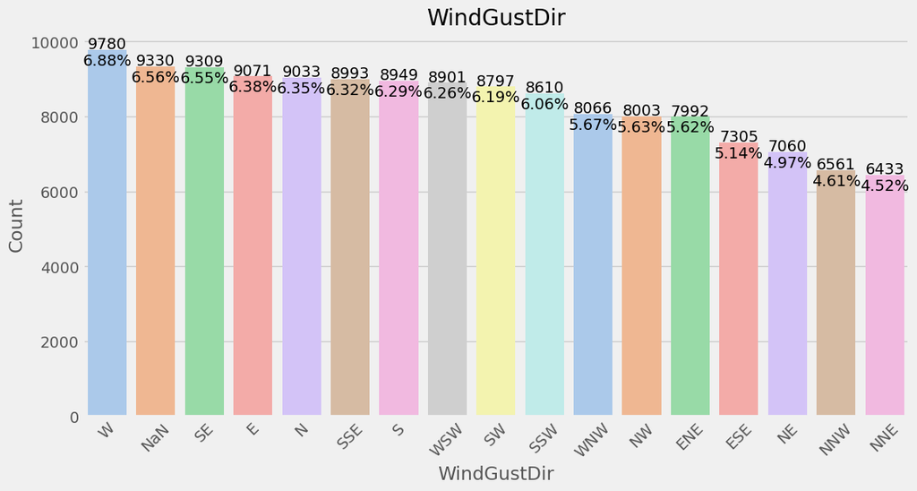

|  | WindGustDir | Count | Percent |
| --- | --- | --- | --- |
| 0 | W | 9780 | 6.877976 |
| 16 | NaN | 9330 | 6.561504 |
| 1 | SE | 9309 | 6.546736 |
| 2 | E | 9071 | 6.379358 |
| 3 | N | 9033 | 6.352633 |
| 4 | SSE | 8993 | 6.324503 |
| 5 | S | 8949 | 6.293559 |
| 6 | WSW | 8901 | 6.259802 |
| 7 | SW | 8797 | 6.186662 |
| 8 | SSW | 8610 | 6.055150 |

```python
windgustdir_unique = grafica_categoricos_null('WindGustDir', df)
windgustdir_unique.head(10)
```

La columna WindGustDir tiene como segundo máximo valor el nulo, así que recomendamos **imputar por la moda** ó **realizar una predicción de la dirección**

#### 4.6 Columna WindDir9am

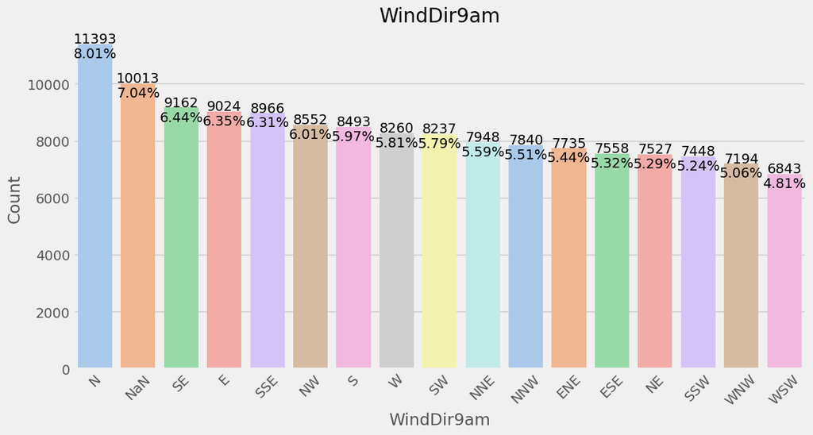

|  | WindDir9am | Count | Percent |
| --- | --- | --- | --- |
| 0 | N | 11393 | 8.012349 |
| 16 | NaN | 10013 | 7.041838 |
| 1 | SE | 9162 | 6.443355 |
| 2 | E | 9024 | 6.346304 |
| 3 | SSE | 8966 | 6.305514 |
| 4 | NW | 8552 | 6.014361 |
| 5 | S | 8493 | 5.972868 |
| 6 | W | 8260 | 5.809006 |
| 7 | SW | 8237 | 5.792831 |
| 8 | NNE | 7948 | 5.589586 |
| 9 | NNW | 7840 | 5.513633 |
| 10 | ENE | 7735 | 5.439790 |
| 11 | ESE | 7558 | 5.315311 |
| 12 | NE | 7527 | 5.293510 |
| 13 | SSW | 7448 | 5.237951 |
| 14 | WNW | 7194 | 5.059321 |
| 15 | WSW | 6843 | 4.812473 |

```python
winddir9am_unique = grafica_categoricos_null('WindDir9am', df)
winddir9am_unique
```

La columna WindDir9am tiene como segundo máximo valor el nulo, así que recomendamos **imputar por la moda** ó **realizar una predicción de la dirección**

#### 4.7 Columna WindDir3pm

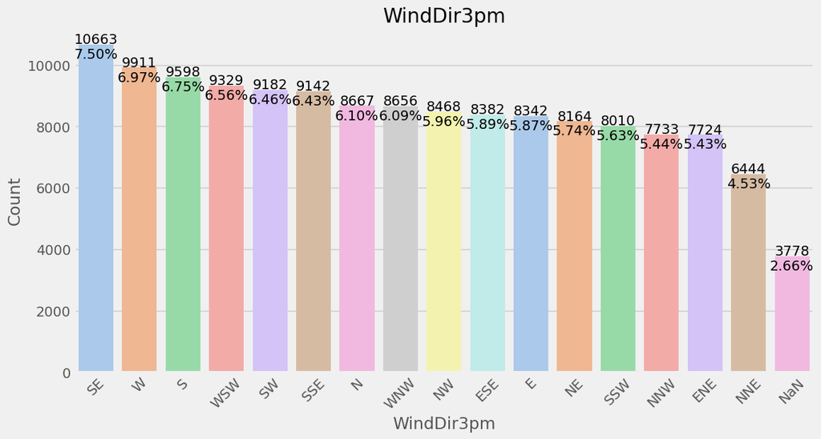

|  | WindDir3pm | Count | Percent |
| --- | --- | --- | --- |
| 0 | SE | 10663 | 7.498963 |
| 1 | W | 9911 | 6.970104 |
| 2 | S | 9598 | 6.749981 |
| 3 | WSW | 9329 | 6.560801 |
| 4 | SW | 9182 | 6.457421 |
| 5 | SSE | 9142 | 6.429290 |
| 6 | N | 8667 | 6.095237 |
| 7 | WNW | 8656 | 6.087501 |
| 8 | NW | 8468 | 5.955286 |
| 9 | ESE | 8382 | 5.894805 |
| 10 | E | 8342 | 5.866674 |
| 11 | NE | 8164 | 5.741492 |
| 12 | SSW | 8010 | 5.633189 |
| 13 | NNW | 7733 | 5.438383 |
| 14 | ENE | 7724 | 5.432054 |
| 15 | NNE | 6444 | 4.531869 |
| 16 | NaN | 3778 | 2.656952 |

```python
winddir3pm_unique = grafica_categoricos_null('WindDir3pm', df)
winddir3pm_unique
```

La columna WindDir3pm tiene como ultimo valor el nulo, así que recomendamos **imputar por la moda**

#### 4.8 Columna RainToday

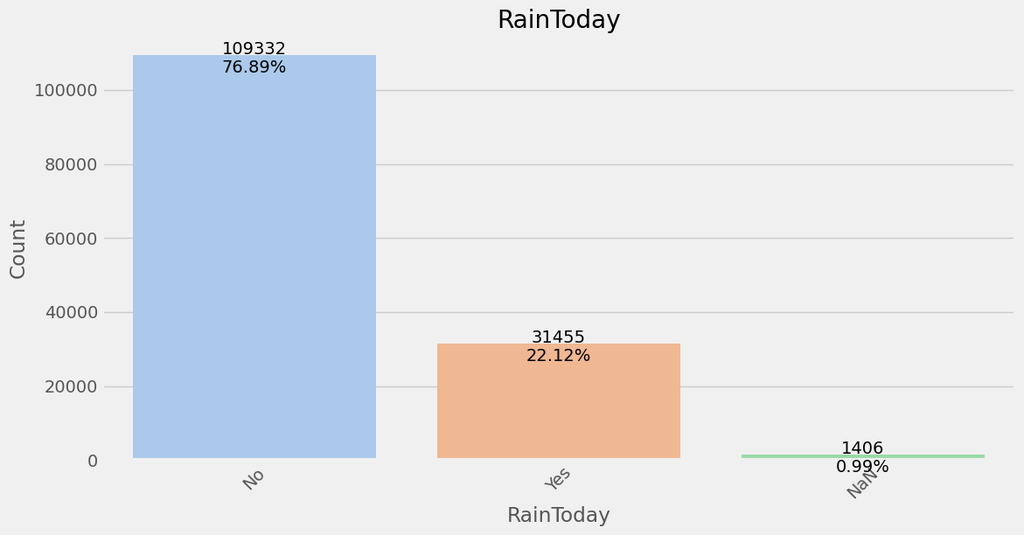

|  | RainToday | Count | Percent |
| --- | --- | --- | --- |
| 0 | No | 109332 | 76.889861 |
| 1 | Yes | 31455 | 22.121342 |
| 2 | NaN | 1406 | 0.988797 |

```python
## traer un subconjunto de datos de la columna raintoday con coincluyendo los valores nulos y ordenarlos de manera descendente
raintoday_unique = grafica_categoricos_null('RainToday', df)
raintoday_unique
```

La columna RainToday tiene como ultimo valor el nulo, así que recomendamos **imputar por la moda**

#### 4.9 Columna RainTomorrow

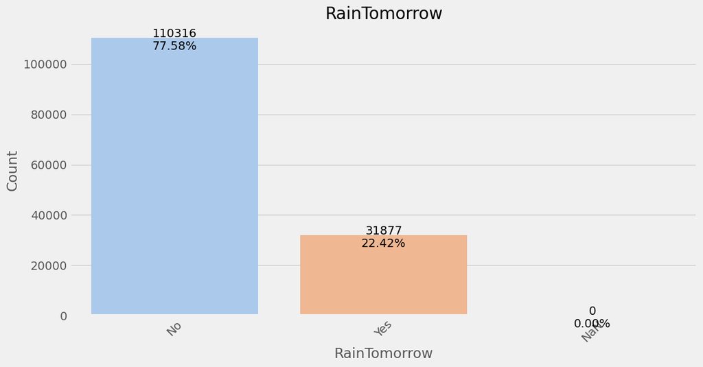

|  | RainTomorrow | Count | Percent |
| --- | --- | --- | --- |
| 0 | No | 110316 | 77.581878 |
| 1 | Yes | 31877 | 22.418122 |
| 2 | NaN | 0 | 0.000000 |

```python
## traer un subconjunto de datos de la columna rain tomorrow con coincluyendo los valores nulos y ordenarlos de manera descendente
raintomorrow_unique = grafica_categoricos_null('RainTomorrow', df)
raintomorrow_unique
```

Se recomienda **igualar las opciones**, ya que esta muy sesgado para eso se puede **agregar** ó **eliminar** registros

## Fase 3: Data Preparation

### Transformación, eliminación e imputación de datos

#### 1. Unificación de datos nulos

- Debido a que es probable que hayan datos nulos escritos de diferentes maneras, dejaremos todos los datos como np.nan

```python
na_values = ('np.nan','NA','NaN','nan','inf','NULL')
df = df.replace(na_values, np.nan)
```

- Función para contar nulos

```python
def cuantos_nulos(df):
    # crear un nuevo dataframe con las columnas que tienen valores nulos
    df_null = df.loc[:, df.isnull().any()]
    # contar la cantidad de columnas
    print(f"El dataset tiene {df_null.shape[1]} columnas con valores nulos, con un total de {df_null.isnull().sum().sum()} filas.")
```

- Cantidad de Nulos antes de las imputaciones

```python
cuantos_nulos(df)
```

```
El dataset tiene 20 columnas con valores nulos, con un total de 316559 filas.
```

#### 2. Variables Númericas

```python
print("Hasta ahora las variables numericas son:")
for col in list_columns_nulls:
    print(f"- {col}")
```

```
Hasta ahora las variables numericas son:
- MaxTemp
- MinTemp
- Temp9am
- WindSpeed9am
- Rainfall
- Humidity9am
- WindSpeed3pm
- Temp3pm
- Humidity3pm
- WindGustSpeed
- Pressure3pm
- Pressure9am
- Cloud9am
- Cloud3pm
- Evaporation
- Sunshine
```

##### 2.1 Predicciones con KNN para las variables numericas

- Imputacion de nulos con KNN y 10% vecinos

Para eso usaremos el 10% de los datos

```python
total_rows = df.shape[0]
neighbors = int(total_rows / 10)
print(f" El 10% de los datos para los vecinos es: {neighbors}")
```

```
 El 10% de los datos para los vecinos es: 14219
```

- Imputación de las columnas numericas desde la que tiene menos nulos a la que más

```python
for col in list_columns_nulls:
    imputer = KNNImputer(n_neighbors=neighbors)
    df[[col]] = imputer.fit_transform(df[[col]])
    cuantos_nulos(df)
```

```
El dataset tiene 19 columnas con valores nulos, con un total de 316237 filas.
El dataset tiene 18 columnas con valores nulos, con un total de 315600 filas.
El dataset tiene 17 columnas con valores nulos, con un total de 314696 filas.
El dataset tiene 16 columnas con valores nulos, con un total de 313348 filas.
El dataset tiene 15 columnas con valores nulos, con un total de 311942 filas.
El dataset tiene 14 columnas con valores nulos, con un total de 310168 filas.
El dataset tiene 13 columnas con valores nulos, con un total de 307538 filas.
El dataset tiene 12 columnas con valores nulos, con un total de 304812 filas.
El dataset tiene 11 columnas con valores nulos, con un total de 301202 filas.
El dataset tiene 10 columnas con valores nulos, con un total de 291932 filas.
El dataset tiene 9 columnas con valores nulos, con un total de 277951 filas.
El dataset tiene 8 columnas con valores nulos, con un total de 263937 filas.
El dataset tiene 7 columnas con valores nulos, con un total de 210280 filas.
El dataset tiene 6 columnas con valores nulos, con un total de 153186 filas.
El dataset tiene 5 columnas con valores nulos, con un total de 92343 filas.
El dataset tiene 4 columnas con valores nulos, con un total de 24527 filas.
```

```python
df.describe().T
```

|  | count | mean | std | min | 25% | 50% | 75% | max |
| --- | --- | --- | --- | --- | --- | --- | --- | --- |
| MinTemp | 142193.0 | 12.186400 | 6.388924 | -8.5 | 7.600000 | 12.000000 | 16.800000 | 33.9 |
| MaxTemp | 142193.0 | 23.226784 | 7.109554 | -4.8 | 17.900000 | 22.700000 | 28.200000 | 48.1 |
| Rainfall | 142193.0 | 2.349974 | 8.423217 | 0.0 | 0.000000 | 0.000000 | 0.800000 | 371.0 |
| Evaporation | 142193.0 | 5.469824 | 3.168114 | 0.0 | 4.000000 | 5.469824 | 5.469824 | 145.0 |
| Sunshine | 142193.0 | 7.624853 | 2.734927 | 0.0 | 7.624853 | 7.624853 | 8.700000 | 14.5 |
| WindGustSpeed | 142193.0 | 39.984292 | 13.138385 | 6.0 | 31.000000 | 39.000000 | 46.000000 | 135.0 |
| WindSpeed9am | 142193.0 | 14.001988 | 8.851082 | 0.0 | 7.000000 | 13.000000 | 19.000000 | 130.0 |
| WindSpeed3pm | 142193.0 | 18.637576 | 8.721551 | 0.0 | 13.000000 | 18.637576 | 24.000000 | 87.0 |
| Humidity9am | 142193.0 | 68.843810 | 18.932077 | 0.0 | 57.000000 | 70.000000 | 83.000000 | 100.0 |
| Humidity3pm | 142193.0 | 51.482606 | 20.532065 | 0.0 | 37.000000 | 51.482606 | 65.000000 | 100.0 |
| Pressure9am | 142193.0 | 1017.653758 | 6.746248 | 980.5 | 1013.500000 | 1017.653758 | 1021.800000 | 1041.0 |
| Pressure3pm | 142193.0 | 1015.258204 | 6.681788 | 977.1 | 1011.000000 | 1015.258204 | 1019.400000 | 1039.6 |
| Cloud9am | 142193.0 | 4.437189 | 2.278080 | 0.0 | 3.000000 | 4.437189 | 6.000000 | 9.0 |
| Cloud3pm | 142193.0 | 4.503167 | 2.104709 | 0.0 | 4.000000 | 4.503167 | 6.000000 | 9.0 |
| Temp9am | 142193.0 | 16.987509 | 6.472166 | -7.2 | 12.300000 | 16.800000 | 21.500000 | 40.2 |
| Temp3pm | 142193.0 | 21.687235 | 6.870771 | -5.4 | 16.700000 | 21.300000 | 26.300000 | 46.7 |
| RISK_MM | 142193.0 | 2.360682 | 8.477969 | 0.0 | 0.000000 | 0.000000 | 0.800000 | 371.0 |

##### 2.2 Eliminacion de los outlieres

- Decidimos utilizar 3 veces el rango intercuartil para los outliers excepto para las variables Rainfall (limite en 200), Evaporation el limite será 80 y para RISK_MM el limite será 200

```python
outliers_count = 0
for col in info_outliers:

    # df.info()
    outliers_prev = int(df[(df[col['column']] < col['q25_30']) | (df[col['column']] > col['q75_30'])].shape[0])
    if outliers_prev != 0:
        df = df[(df[col['column']] >= col['q25_30']) & (df[col['column']] <= col['q75_30'])]
        outliers = df[(df[col['column']] < col['q25_30']) | (df[col['column']] > col['q75_30'])].shape[0]
        outliers_count += outliers_prev
        print(f"Para la columna {col['column']} tenemos {outliers_prev} outliers y se eliminaron {outliers_count} outliers. en total")
```

```
Para la columna Rainfall tenemos 14 outliers y se eliminaron 14 outliers. en total
Para la columna Evaporation tenemos 4 outliers y se eliminaron 18 outliers. en total
Para la columna WindGustSpeed tenemos 150 outliers y se eliminaron 168 outliers. en total
Para la columna WindSpeed9am tenemos 96 outliers y se eliminaron 264 outliers. en total
Para la columna WindSpeed3pm tenemos 54 outliers y se eliminaron 318 outliers. en total
Para la columna Pressure9am tenemos 8 outliers y se eliminaron 326 outliers. en total
Para la columna Pressure3pm tenemos 3 outliers y se eliminaron 329 outliers. en total
Para la columna RISK_MM tenemos 13 outliers y se eliminaron 342 outliers. en total
```

#### 3. Variables Categoricas

##### 3.1 Eliminacion de Date

- Ya que no es relevante para el modelo

```python
# eliminar variable date
df.drop('Date', axis=1, inplace=True)
list_columns = df.columns.to_list()
```

##### 3.2 One-hot Encoding de Location

```python
#one hot encoding para la columna location y eliminar la columna original location y dejarla como 0 y 1
df = pd.get_dummies(df, columns=['Location'], drop_first=True)
# obtener las columnas obtenidas con one hot encoding
location_columns = df.filter(like='Location').columns
location_columns.to_list()
location_columns = location_columns.to_list()
for column in location_columns:
    list_columns.append(column)
```

##### 3.3 One-hot Encoding de RainTomorrow

```python
# one hot encoding para la columna raintomorrow y eliminar la columna original raintomorrow y dejarla como 0 y 1
df = pd.get_dummies(df, columns=['RainTomorrow'], drop_first=True)
df.head(5)
```

|  | MinTemp | MaxTemp | Rainfall | Evaporation | Sunshine | WindGustDir | WindGustSpeed | WindDir9am | WindDir3pm | WindSpeed9am | ... | Location_Tuggeranong | Location_Uluru | Location_WaggaWagga | Location_Walpole | Location_Watsonia | Location_Williamtown | Location_Witchcliffe | Location_Wollongong | Location_Woomera | RainTomorrow_Yes |
| --- | --- | --- | --- | --- | --- | --- | --- | --- | --- | --- | --- | --- | --- | --- | --- | --- | --- | --- | --- | --- | --- |
| 0 | 13.4 | 22.9 | 0.6 | 5.469824 | 7.624853 | W | 44.0 | W | WNW | 20.0 | ... | False | False | False | False | False | False | False | False | False | False |
| 1 | 7.4 | 25.1 | 0.0 | 5.469824 | 7.624853 | WNW | 44.0 | NNW | WSW | 4.0 | ... | False | False | False | False | False | False | False | False | False | False |
| 2 | 12.9 | 25.7 | 0.0 | 5.469824 | 7.624853 | WSW | 46.0 | W | WSW | 19.0 | ... | False | False | False | False | False | False | False | False | False | False |
| 3 | 9.2 | 28.0 | 0.0 | 5.469824 | 7.624853 | NE | 24.0 | SE | E | 11.0 | ... | False | False | False | False | False | False | False | False | False | False |
| 4 | 17.5 | 32.3 | 1.0 | 5.469824 | 7.624853 | W | 41.0 | ENE | NW | 7.0 | ... | False | False | False | False | False | False | False | False | False | False |

5 rows × 70 columns

- Lista de variables numericas

```python
# lista de columnas float o bool
list_columns = df.select_dtypes(include=['float64', 'bool']).columns.to_list()
```

- Función para imputar valores faltantes con Decision Tree Classifier, ya que los nulos serán predichos con DTC

```python
def imputar_valores_faltantes(df, list_columns, column_target):
    # Cargar el conjunto de datos
    data = df[list_columns]
    if df.columns.duplicated().any():
        df = df.loc[:, ~df.columns.duplicated()]
    # Separar los datos en parte conocida (no nulos) y parte desconocida (nulos)
    known_data = data.dropna(subset=[column_target])  # Eliminar filas con valores nulos en 'WindGustDir'
    X_known = known_data.drop(columns=[column_target])
    y_known = known_data[column_target]
    X_unknown = data[data[column_target].isnull()].drop(columns=[column_target])

    # Entrenar el modelo de clasificación (en este caso, un clasificador de árbol de decisiones)
    clf = DecisionTreeClassifier()
    clf.fit(X_known, y_known)

    # Predecir valores faltantes
    y_pred = clf.predict(X_unknown)

    # # Reemplazar los valores faltantes con las predicciones realizadas por el modelo de clasificación al dataframe originil
    df.loc[df[column_target].isnull(), column_target] = y_pred
    return df
```

##### 3.4 Prediccion de windGustDir

- Cantidad de nulos en WindGustDir

```python
df['WindGustDir'].isna().sum()
```

```
9288
```

- Imputar WindGustDir

```python
# agregar la columna WindGustDir a la lista list_columns
list_columns.append('WindGustDir')
df = imputar_valores_faltantes(df, list_columns, 'WindGustDir')
```

- Nulos luego de la imputación

```python
df[list_columns].isnull().sum().sum()
```

```
0
```

- One-hot Encoding de WindGustDir

```python
# one hot enconding para la columna WindGustDir y eliminar la columna original WindGustDir y dejarla como 0 y 1
df = pd.get_dummies(df, columns=['WindGustDir'], drop_first=True)
# agregar las columnas obtenidas con one hot encoding a la lista list_columns y eliminar la columna original WindGustDir
windgustdir_columns = df.filter(like='WindGustDir').columns
windgustdir_columns = windgustdir_columns.to_list()
for column in windgustdir_columns:
    list_columns.append(column)

# drop columna WindGustDir
list_columns.remove('WindGustDir')
df.head()
```

|  | MinTemp | MaxTemp | Rainfall | Evaporation | Sunshine | WindGustSpeed | WindDir9am | WindDir3pm | WindSpeed9am | WindSpeed3pm | ... | WindGustDir_NNW | WindGustDir_NW | WindGustDir_S | WindGustDir_SE | WindGustDir_SSE | WindGustDir_SSW | WindGustDir_SW | WindGustDir_W | WindGustDir_WNW | WindGustDir_WSW |
| --- | --- | --- | --- | --- | --- | --- | --- | --- | --- | --- | --- | --- | --- | --- | --- | --- | --- | --- | --- | --- | --- |
| 0 | 13.4 | 22.9 | 0.6 | 5.469824 | 7.624853 | 44.0 | W | WNW | 20.0 | 24.0 | ... | False | False | False | False | False | False | False | True | False | False |
| 1 | 7.4 | 25.1 | 0.0 | 5.469824 | 7.624853 | 44.0 | NNW | WSW | 4.0 | 22.0 | ... | False | False | False | False | False | False | False | False | True | False |
| 2 | 12.9 | 25.7 | 0.0 | 5.469824 | 7.624853 | 46.0 | W | WSW | 19.0 | 26.0 | ... | False | False | False | False | False | False | False | False | False | True |
| 3 | 9.2 | 28.0 | 0.0 | 5.469824 | 7.624853 | 24.0 | SE | E | 11.0 | 9.0 | ... | False | False | False | False | False | False | False | False | False | False |
| 4 | 17.5 | 32.3 | 1.0 | 5.469824 | 7.624853 | 41.0 | ENE | NW | 7.0 | 20.0 | ... | False | False | False | False | False | False | False | True | False | False |

5 rows × 84 columns

##### 3.5 Prediccion a WindDir9am

- Cantidad de nulos antes de la imputación

```python
list_columns.append('WindDir9am')
df['WindDir9am'].isna().sum()
```

```
10006
```

- Cantidad de nulos despues de la imputación

```python
df = imputar_valores_faltantes(df, list_columns, 'WindDir9am')
list_columns.remove('WindDir9am')
df[list_columns].isnull().sum().sum()
```

```
0
```

- One-Hot Encoding de WindDir9am

```python
df = pd.get_dummies(df, columns=['WindDir9am'], drop_first=True)
# agregar las columnas obtenidas con one hot encoding a la lista list_columns y eliminar la columna original WindGustDir
windgustdir_columns = df.filter(like='WindDir9am').columns
windgustdir_columns = windgustdir_columns.to_list()
for column in windgustdir_columns:
    list_columns.append(column)
```

##### 3.6 Prediccion a WindDir3pm

- - Cantidad de nulos antes de la imputación

```python
list_columns.append('WindDir3pm')
df['WindDir3pm'].isna().sum()
```

```
3759
```

- Cantidad de despues antes de la imputación

```python
df = imputar_valores_faltantes(df, list_columns, 'WindDir3pm')
list_columns.remove('WindDir3pm')
df[list_columns].isnull().sum().sum()
```

```
0
```

- One-Hot Enconding WindDir3pm

```python
df = pd.get_dummies(df, columns=['WindDir3pm'], drop_first=True)
# agregar las columnas obtenidas con one hot encoding a la lista list_columns y eliminar la columna original WindGustDir
windgustdir_columns = df.filter(like='WindDir3pm').columns
windgustdir_columns = windgustdir_columns.to_list()
for column in windgustdir_columns:
    list_columns.append(column)
```

##### 3.7 Imputar RainToday

- Cantidad de nulos antes de la imputación

```python
list_columns.append('RainToday')
df['RainToday'].isna().sum()
```

```
1402
```

- Cantidad de nulos despues de la imputación

```python
# imputar la moda de la columna RainToday
df['RainToday'] = df['RainToday'].fillna(df['RainToday'].mode()[0])
df[list_columns].isnull().sum().sum()
```

```
0
```

- One-Hot Enconding RainToday

```python
df = pd.get_dummies(df, columns=['RainToday'], drop_first=True)
# agregar las columnas obtenidas con one hot encoding a la lista list_columns y eliminar la columna original WindGustDir
windgustdir_columns = df.filter(like='RainToday').columns
windgustdir_columns = windgustdir_columns.to_list()
for column in windgustdir_columns:
    list_columns.append(column)
```

##### 3.8 Nulos Totales

```python
# imprimir los valores nulos del dataframe
df.isnull().sum().sum()
```

```
0
```

```python
df.head()
```

|  | MinTemp | MaxTemp | Rainfall | Evaporation | Sunshine | WindGustSpeed | WindSpeed9am | WindSpeed3pm | Humidity9am | Humidity3pm | ... | WindDir3pm_NW | WindDir3pm_S | WindDir3pm_SE | WindDir3pm_SSE | WindDir3pm_SSW | WindDir3pm_SW | WindDir3pm_W | WindDir3pm_WNW | WindDir3pm_WSW | RainToday_Yes |
| --- | --- | --- | --- | --- | --- | --- | --- | --- | --- | --- | --- | --- | --- | --- | --- | --- | --- | --- | --- | --- | --- |
| 0 | 13.4 | 22.9 | 0.6 | 5.469824 | 7.624853 | 44.0 | 20.0 | 24.0 | 71.0 | 22.0 | ... | False | False | False | False | False | False | False | True | False | False |
| 1 | 7.4 | 25.1 | 0.0 | 5.469824 | 7.624853 | 44.0 | 4.0 | 22.0 | 44.0 | 25.0 | ... | False | False | False | False | False | False | False | False | True | False |
| 2 | 12.9 | 25.7 | 0.0 | 5.469824 | 7.624853 | 46.0 | 19.0 | 26.0 | 38.0 | 30.0 | ... | False | False | False | False | False | False | False | False | True | False |
| 3 | 9.2 | 28.0 | 0.0 | 5.469824 | 7.624853 | 24.0 | 11.0 | 9.0 | 45.0 | 16.0 | ... | False | False | False | False | False | False | False | False | False | False |
| 4 | 17.5 | 32.3 | 1.0 | 5.469824 | 7.624853 | 41.0 | 7.0 | 20.0 | 82.0 | 33.0 | ... | True | False | False | False | False | False | False | False | False | False |

5 rows × 112 columns

#### 4. Visualización de datos limpios

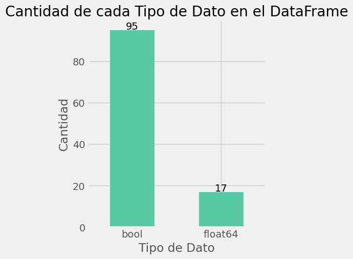

```python
data_types_counts = df.dtypes.value_counts()

plt.figure(figsize=(4, 5))
ax = data_types_counts.plot(kind='bar', rot=0, color='#59c9a5')

for p in ax.patches:
    ax.annotate(str(p.get_height()), (p.get_x() + p.get_width() / 2., p.get_height()),
                ha='center', va='center', xytext=(0, 5), textcoords='offset points', color='black')

plt.xlabel('Tipo de Dato')
plt.ylabel('Cantidad')
plt.title('Cantidad de cada Tipo de Dato en el DataFrame', color='black')
plt.show()
```

#### 5. Escalado de los datos

```python
# normalizacion minmaxescaler para las columnas float
scaler = MinMaxScaler()
# lista de columnas float
list_columns = df.select_dtypes(include=['float64']).columns.to_list()
df[list_columns] = scaler.fit_transform(df[list_columns])
df[list_columns].describe().T
```

|  | count | mean | std | min | 25% | 50% | 75% | max |
| --- | --- | --- | --- | --- | --- | --- | --- | --- |
| MinTemp | 141851.0 | 0.487827 | 0.150703 | 0.0 | 0.379717 | 0.483491 | 0.596698 | 1.0 |
| MaxTemp | 141851.0 | 0.529875 | 0.134328 | 0.0 | 0.431002 | 0.519849 | 0.623819 | 1.0 |
| Rainfall | 141851.0 | 0.011999 | 0.041301 | 0.0 | 0.000000 | 0.000000 | 0.004167 | 1.0 |
| Evaporation | 141851.0 | 0.070698 | 0.040369 | 0.0 | 0.051746 | 0.070761 | 0.070761 | 1.0 |
| Sunshine | 141851.0 | 0.526087 | 0.188503 | 0.0 | 0.525852 | 0.525852 | 0.600000 | 1.0 |
| WindGustSpeed | 141851.0 | 0.368163 | 0.140172 | 0.0 | 0.271739 | 0.358696 | 0.434783 | 1.0 |
| WindSpeed9am | 141851.0 | 0.258221 | 0.161654 | 0.0 | 0.129630 | 0.240741 | 0.351852 | 1.0 |
| WindSpeed3pm | 141851.0 | 0.326039 | 0.151248 | 0.0 | 0.228070 | 0.326975 | 0.421053 | 1.0 |
| Humidity9am | 141851.0 | 0.688548 | 0.189240 | 0.0 | 0.570000 | 0.700000 | 0.830000 | 1.0 |
| Humidity3pm | 141851.0 | 0.514676 | 0.205174 | 0.0 | 0.370000 | 0.514826 | 0.650000 | 1.0 |
| Pressure9am | 141851.0 | 0.587906 | 0.118832 | 0.0 | 0.514134 | 0.587522 | 0.660777 | 1.0 |
| Pressure3pm | 141851.0 | 0.578472 | 0.115482 | 0.0 | 0.504333 | 0.578132 | 0.649913 | 1.0 |
| Cloud9am | 141851.0 | 0.492826 | 0.253076 | 0.0 | 0.333333 | 0.493021 | 0.666667 | 1.0 |
| Cloud3pm | 141851.0 | 0.500101 | 0.233819 | 0.0 | 0.444444 | 0.500352 | 0.666667 | 1.0 |
| Temp9am | 141851.0 | 0.510271 | 0.136542 | 0.0 | 0.411392 | 0.506329 | 0.605485 | 1.0 |
| Temp3pm | 141851.0 | 0.520006 | 0.131818 | 0.0 | 0.424184 | 0.512476 | 0.608445 | 1.0 |
| RISK_MM | 141851.0 | 0.012026 | 0.041476 | 0.0 | 0.000000 | 0.000000 | 0.004167 | 1.0 |

#### 6. Balanceo de datos

- Ya que los datos de si llueve mañana o no estan disparejos, se decidio balanciar los datos agregando datos a la opcion que tenia menos valores (Si llueve)

```python
# generar con SMOTE un dataset balanceado para la columna RainTomorrow_Yes

# instanciar el objeto SMOTE
smote = SMOTE(random_state=42)
# generar el dataset balanceado
X, y = df.drop(columns=['RainTomorrow_Yes'], axis=1), df['RainTomorrow_Yes']
X_smote, y_smote = smote.fit_resample(X, y)
# crear un nuevo dataframe con los datos balanceados
df_smote = pd.concat([X_smote, y_smote], axis=1)
# imprimir la cantidad de valores de la columna RainTomorrow_Yes
df_smote['RainTomorrow_Yes'].value_counts()

df_smote.head()
```

|  | MinTemp | MaxTemp | Rainfall | Evaporation | Sunshine | WindGustSpeed | WindSpeed9am | WindSpeed3pm | Humidity9am | Humidity3pm | ... | WindDir3pm_S | WindDir3pm_SE | WindDir3pm_SSE | WindDir3pm_SSW | WindDir3pm_SW | WindDir3pm_W | WindDir3pm_WNW | WindDir3pm_WSW | RainToday_Yes | RainTomorrow_Yes |
| --- | --- | --- | --- | --- | --- | --- | --- | --- | --- | --- | --- | --- | --- | --- | --- | --- | --- | --- | --- | --- | --- |
| 0 | 0.516509 | 0.523629 | 0.003125 | 0.070761 | 0.525852 | 0.413043 | 0.370370 | 0.421053 | 0.71 | 0.22 | ... | False | False | False | False | False | False | True | False | False | False |
| 1 | 0.375000 | 0.565217 | 0.000000 | 0.070761 | 0.525852 | 0.413043 | 0.074074 | 0.385965 | 0.44 | 0.25 | ... | False | False | False | False | False | False | False | True | False | False |
| 2 | 0.504717 | 0.576560 | 0.000000 | 0.070761 | 0.525852 | 0.434783 | 0.351852 | 0.456140 | 0.38 | 0.30 | ... | False | False | False | False | False | False | False | True | False | False |
| 3 | 0.417453 | 0.620038 | 0.000000 | 0.070761 | 0.525852 | 0.195652 | 0.203704 | 0.157895 | 0.45 | 0.16 | ... | False | False | False | False | False | False | False | False | False | False |
| 4 | 0.613208 | 0.701323 | 0.005208 | 0.070761 | 0.525852 | 0.380435 | 0.129630 | 0.350877 | 0.82 | 0.33 | ... | False | False | False | False | False | False | False | False | False | False |

5 rows × 112 columns

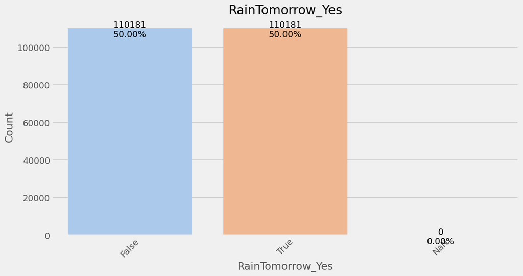

|  | RainTomorrow_Yes | Count | Percent |
| --- | --- | --- | --- |
| 0 | False | 110181 | 50.0 |
| 1 | True | 110181 | 50.0 |
| 2 | NaN | 0 | 0.0 |

```python
# graficar la cantidad de valores de la columna RainTomorrow_Yes con la funcion definida anteriormente
grafica_categoricos_null('RainTomorrow_Yes', df_smote)
```